# R Notebook

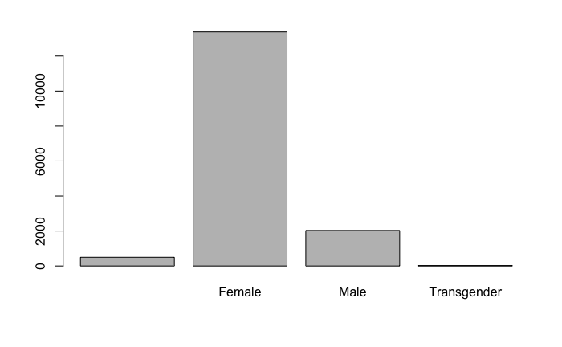

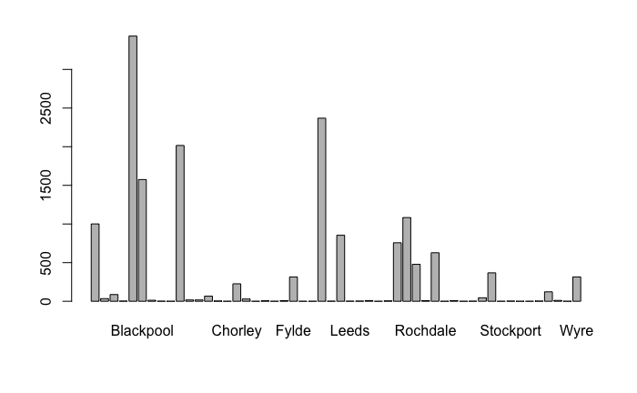

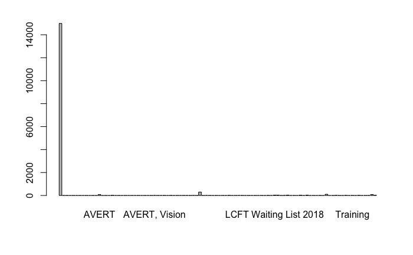

```r
summary(users_clean)
```

```
   Person.ID          Age                                Ward                    Local_Authority
 Min.   :   59   Min.   :  0.00                            : 1001   Blackburn with Darwen:3431
 1st Qu.: 9220   1st Qu.: 28.00   Wensley Fold             :  325   Hyndburn             :2369
 Median :13717   Median : 39.00   Shadsworth with Whitebirk:  310   Burnley              :2016
 Mean   :13568   Mean   : 39.28   Audley                   :  262   Blackpool            :1575
 3rd Qu.:18298   3rd Qu.: 51.00   Ewood                    :  243   Preston              :1083
 Max.   :22579   Max.   :107.00   Spring Hill              :  236                        :1001
                                  (Other)                  :13560   (Other)              :4462
    Outcode             Gender                               Ethnicity              Religion
 BB5    :1883              :  499   A - White British             :11486   L - None     :5333
 BB2    :1481   Female     :13381                                 : 2420                :4547
 BB1    :1466   Male       : 2033   J - Pakistani                 :  845   C - Christian:4219
        : 852   Transgender:   24   H - Indian                    :  271   G - Muslim   :1176
 BB11   : 751                       C - Any other White background:  224   K - Other    : 478
 BB10   : 690                       B - White Irish               :  153   B - Buddhist :  69
 (Other):8814                       (Other)                       :  538   (Other)      : 115
 Referred       Referral_Date                         Referral_Source    Registered_Centre
    :    1             : 1072   B1 - Self                     :3852   Accrington  :2936
 No :  242   02/11/2015:   59   A1 - GP                       :2277   Burnley     :2876
 Yes:15694   11/01/2018:   58   E1 - Police                   :1792   Blackpool   :2117
             28/04/2017:   52   G4 - Voluntary Sector         :1629   Blackburn   :1964
             01/08/2017:   50   E3 - Probation Service        :1340   Preston     :1786
             07/04/2016:   49   A3 - Other Primary Health Care: 778   Blackburn WS:1432
             (Other)   :14597   (Other)                       :4269   (Other)     :2826
                                                             Initial_Project
 Therapeutic Services - 1 to 1 (counselling, CBT)                    :4792
 Housing, Money & Debt Advice                                        :1728
 Vision                                                              :1536
 AVERT                                                               :1520
                                                                     :1295
 Therapeutic Services - Group (SEE, Butterfly, Stepping Stones, etc.):1050
 (Other)                                                             :4016
        Sexual_Orientation  Domestic_Abuse  No__of_Children  Long_Term_Mental_Health_Condition
                 : 4629            :13173   Min.   : 0.000          :8207
 1 - Heterosexual:10735    Current :  387   1st Qu.: 0.000   N - No :4120
 2 - Gay/Lesbian :  296    Historic: 1983   Median : 1.000   Y - Yes:3610
 3 - Bi-sexual   :  277    None    :  394   Mean   : 1.132
                                            3rd Qu.: 2.000
                                            Max.   :10.000
                                            NA's   :7480
```

[output cut: 89 more lines]

```
           : 1655              : 1646    Min.   :0.0000   Min.   :0.0000   Min.   :0.0000
 2017-11-23:   42    2018-11-07:  122    1st Qu.:0.0000   1st Qu.:0.0000   1st Qu.:0.0000
 2015-11-18:   38    2018-11-06:   96    Median :1.0000   Median :0.0000   Median :0.0000
 2018-02-23:   37    2018-11-08:   93    Mean   :0.6635   Mean   :0.2406   Mean   :0.0597
 2015-11-05:   36    2018-11-05:   88    3rd Qu.:1.0000   3rd Qu.:0.0000   3rd Qu.:0.0000
 2016-04-25:   36    2018-10-17:   76    Max.   :1.0000   Max.   :1.0000   Max.   :1.0000
 (Other)   :14093    (Other)   :13816    NA's   :1608     NA's   :1608     NA's   :1608
  Money_advice       Unknown
 Min.   :0.0000   Min.   :0.000
 1st Qu.:0.0000   1st Qu.:0.000
 Median :0.0000   Median :0.000
 Mean   :0.2541   Mean   :0.047
 3rd Qu.:1.0000   3rd Qu.:0.000
 Max.   :1.0000   Max.   :1.000
 NA's   :1608     NA's   :1608
```

```r
mean(mean_per_person$x)
```

```
[1] 0.7409001
```

| Group.1 | x |
| --- | --- |
| Employment | 176.78505 |
| Mental_health | 181.52509 |
| Money_advice | 127.22659 |
| Unknown | 26.56231 |
| Women_at_risk | 221.56078 |

```r
#cbt pwp counselling 3 main therapy groups
# does being a part of multiple workstreams means better chance of success in mental health outcome
attach(mental_health_outcomes)
```

do users achieve recovery

```r
recovery_flag<-(aggregate(mental_health_outcomes[, 24], list(mental_health_outcomes$Person.ID), max))
summary(as.factor(recovery_flag$x))
```

```
   0    1 NA's
5181 2562  804
```

```r
#total
#8547 patients
#recovery
#2562/(5181+2562)= 33% people recovered
```

20-29 low -pdp or groups 40-51 high 42,44,46,48,51-counselling others cbt

5-item self-report measure which provides an experiential impact of a disorder from the patient’s point of view. It looks at how the disorder impairs the patient’s ability to function day to day with depression and / or anxiety as well as phobic disorders.

Social phobia 0-8

Agoraphobia 0-8

Specific phobia 0-8

COPD score 0-40 Assess severity of COPD (Chronic Obstructive Pulmonary Disease)

PHQ15 score 0-30 –>5: mild , >10: moderate , >15: severe Assess severity of somatic symptoms Pain score 0-90 Assesses how pain has interfered with general life in the last 24 hrs.

Diabetes distress score 0-102 Total score > 51 is a distress level worthy of clinical attention.

Does (soft) outcome depend on the service user’s background?

```r
# code all soft outcomes into groups if needed
#phq 15
# 0-5 none
# >5 mild
# >10 moderate
# >15 severe
#mental_health_outcomes$PHQ15_score_new<-as.numeric(mental_health_outcomes$PHQ15_scor
# (mental_health_outcomes$PHQ15_score_new[PHQ15_score >= 0 & PHQ15_score <= 5]) <- "0"
# mental_health_outcomes$PHQ15_score_new[PHQ15_score > 5 & PHQ15_score <= 10] <- "1"
# mental_health_outcomes$PHQ15_score_new[PHQ15_score > 10 & PHQ15_score <= 15] <- "2"
# mental_health_outcomes$PHQ15_score_new[PHQ15_score > 15 ] <- "3"
# mental_health_outcomes$PHQ15_score_new<-as.factor(mental_health_outcomes$PHQ15_score_new)
# summary(mental_health_outcomes$PHQ15_score_new)
#  Mild     Moderate        None        Severe       NA's
#     150      115       94      125    46661
summary(mental_health_outcomes$PHQ15_score)
```

```
   Min. 1st Qu.  Median    Mean 3rd Qu.    Max.    NA's
    0.0     6.0    10.0    11.3    16.0    30.0   46661
```

Diabetes distress score 0-102 Total score > 51 is a distress level worthy of clinical attention.

```r
#mental_health_outcomes$Diabetes_distress_score_new<-as.numeric(mental_health_outcomes$Diabetes_distress_score_new)
mental_health_outcomes$Diabetes_distress_score_new[Diabetes_distress_score <=51 ] <- "0"
mental_health_outcomes$Diabetes_distress_score_new[Diabetes_distress_score >51 ] <- "1"
mental_health_outcomes$Diabetes_distress_score_new<-as.factor(mental_health_outcomes$Diabetes_distress_score_new)
summary(mental_health_outcomes$Diabetes_distress_score_new)
```

```
    0     1  NA's
   82    10 47053
```

```r
#  0     1  NA's
 #  82    10 47053
```

check na’s in other measures Social phobia 0-8 Agoraphobia 0-8 Specific phobia 0-8 COPD score 0-40 Assess severity of COPD (Chronic Obstructive Pulmonary Disease) PHQ15 score 0-30 Assess severity of somatic symptoms Pain score 0-90 Assesses how pain has interfered with general life in the last 24 hrs. Diabetes distress score 0-102

```r
#total rows 47145
summary(mental_health_outcomes$Social_phobia) #1948 na's
```

```
   Min. 1st Qu.  Median    Mean 3rd Qu.    Max.    NA's
  0.000   1.000   3.000   3.134   5.000   8.000    1948
```

```r
summary(mental_health_outcomes$Agoraphobia)# 1977 na's
```

```
   Min. 1st Qu.  Median    Mean 3rd Qu.    Max.    NA's
  0.000   0.000   2.000   2.735   5.000   8.000    1977
```

```r
summary(mental_health_outcomes$Specific_phobia) #2096 na's
```

```
   Min. 1st Qu.  Median    Mean 3rd Qu.    Max.    NA's
  0.000   0.000   1.000   2.345   4.000   8.000    2096
```

```r
summary(mental_health_outcomes$COPD_score) #47039
```

```
   Min. 1st Qu.  Median    Mean 3rd Qu.    Max.    NA's
   0.00   18.25   25.00   23.75   31.75   40.00   47039
```

```r
summary(mental_health_outcomes$PHQ15_score)# 46661
```

```
   Min. 1st Qu.  Median    Mean 3rd Qu.    Max.    NA's
    0.0     6.0    10.0    11.3    16.0    30.0   46661
```

```r
summary(mental_health_outcomes$Pain_score)#46839 na's
```

```
   Min. 1st Qu.  Median    Mean 3rd Qu.    Max.    NA's
   0.00   27.25   42.00   39.41   53.00   70.00   46839
```

```r
summary(mental_health_outcomes$Diabetes_distress_score) #47053
```

```
   Min. 1st Qu.  Median    Mean 3rd Qu.    Max.    NA's
   0.00   10.00   24.50   26.74   38.00   89.00   47053
```

```r
summary(mental_health_outcomes$GAD7)#77 na's
```

```
   Min. 1st Qu.  Median    Mean 3rd Qu.    Max.    NA's
   0.00    7.00   12.00   11.36   16.00   21.00      77
```

```r
summary(mental_health_outcomes$PHQ9)# 23 na's
```

```
   Min. 1st Qu.  Median    Mean 3rd Qu.    Max.    NA's
   0.00    8.00   12.00   12.69   18.00   27.00      23
```

there are a lot of na’s in some of the measures. might be worth not using all of them (not using last 4?)

first lets figure out if there is an improvement in self scoring need to find max and min for each score for each user. need to roll up by user and aggregate on max and min dates for each score

Social_phobia) #1948 na’s Agoraphobia)# 1977 na’s Specific_phobia) #2096 na’s COPD_score) #47039 PHQ15_score_new)# 46661 Pain_score)#46839 na’s Diabetes_distress_score_new) #47053 GAD #77 PHQ9 #23

```r
summary(earliest_scores$Social_phobia)
```

```
   Min. 1st Qu.  Median    Mean 3rd Qu.    Max.    NA's
  0.000   1.000   3.000   3.483   6.000   8.000     530
```

```r
earliest_scores<-earliest_scores[!is.na(earliest_scores$Social_phobia), ]
earliest_scores<-earliest_scores[!is.na(earliest_scores$Agoraphobia), ]
earliest_scores<-earliest_scores[!is.na(earliest_scores$Specific_phobia), ]
```

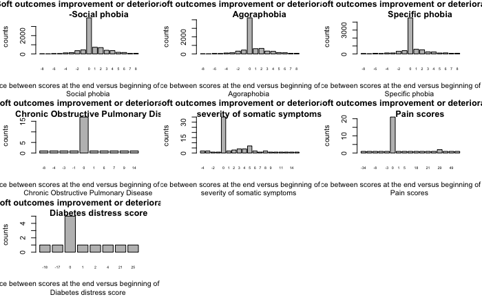

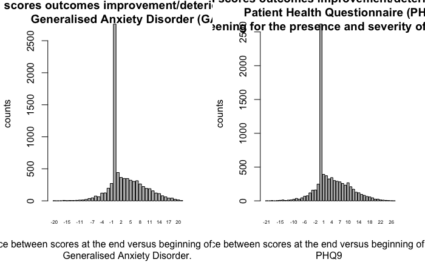

try run a model on gad and phq to see if there is any dependency with user info and outcomes first join differences table and users table

```r
all_scores_users_1$On_Benefits[all_scores_users_1$On_Benefits==""] <- 0
```

```
invalid factor level, NA generated
```

```r
all_scores_users_1<-final[complete.cases(all_scores_users_1), ]
```

```
Error: object 'final' not found
```

can run logistic regression for gad and phq. need to code gad>0 as 1 and <=0 as 0. same for phq

```r
all_scores_users_1$GAD_difference1[GAD_difference >0 ] <- "1"
```

```
Error in all_scores_users_1$GAD_difference1[GAD_difference > 0] <- "1" :
  object 'GAD_difference' not found
```

add diagnosis

```r
all_scores_users_2<-merge(all_scores_users_1,mental_health_referal,by.x=c("Group.1"),by.y=c("Person.ID"))
```

```
Error in as.data.frame(y) : object 'mental_health_referal' not found
```

try random forest

```r
train_ind <- sample(seq_len(nrow(all_scores_users_1)), size = smp_size)
train <- all_scores_users_1[train_ind, ]
test <- all_scores_users_1[-train_ind, ]
library(textir) ## needed to standardize the data
library(class) ## needed for knn
library(ggplot2) # visualization
library(ggthemes) # visualization
library(scales) # visualization
library(dplyr) # data manipulation
```

```
Error in loadNamespace(j <- i[[1L]], c(lib.loc, .libPaths()), versionCheck = vI[[j]]) :
  namespace ‘Rcpp’ 0.12.14 is already loaded, but >= 0.12.16 is required
Error: package or namespace load failed for ‘dplyr’
```

```r
train_train <- train[1:3948,]
test_train <- train[3949:5235,]
summary(train_train$PHQ9_difference1)
```

[output not shown]

```r
print(output.forest)
```

```
Call:
 randomForest(formula = train_train$PHQ9_difference1 ~ ., data = train_train[,      c(6, 8, 9, 10, 11, 13, 14, 15, 16, 17, 18, 19, 20, 21, 22,          23)], importance = T)
               Type of random forest: classification
                     Number of trees: 500
No. of variables tried at each split: 4

        OOB estimate of  error rate: 35.51%
Confusion matrix:
     0    1 class.error
0 1521  302   0.1656610
1 1100 1025   0.5176471
```

```r
(importance(output.forest))
```

```
                                              0           1 MeanDecreaseAccuracy MeanDecreaseGini
Age                                   3.7054648  0.81502318            2.7696521       207.013142
Local_Authority                       0.0000000  0.00000000            0.0000000       149.249357
Gender                                2.5753580  1.05698725            2.4936999        27.461034
Ethnicity                             0.9335295 -2.92952076           -1.7853390        61.100346
Referred                             -4.1718231  1.50996352           -3.4872139         1.050072
Registered_Centre                    11.4909661 -1.31513621            5.4456031       134.251348
Sexual_Orientation                    0.9448912  1.81207694            2.1809439        34.304151
Long_Term_Physical_Health_Condition_  3.0389894  1.39743664            3.1461066        62.259514
British_Armed_Forces                  0.4516991 -0.04900176            0.2338822        37.310120
Sum_of_hours_attended                18.3881863 15.41248878           23.0653184       296.247195
Count_of_sessions_attended           47.8195090 46.00151018           60.5383366       585.045088
Domestic_Abuse                        1.6278827  0.79300739            1.6853062        38.995784
Personal_Circumstances                0.3607556  2.37510383            2.3661235        53.012211
Income                                4.9429193 -0.19390685            2.2488042       131.580241
Unemployed_Since                     -0.9265480  5.43904612            4.4163092        40.589177
On_Benefits                           4.4171993  0.77140290            2.9682386        53.974314
```

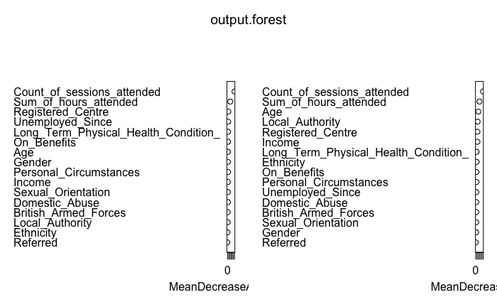

```r
varImpPlot(output.forest)
```

```r
rankImportance <- varImportance %>% mutate(Rank = paste0('#',dense_rank(desc(Importance))))
```

```
Error in mutate_impl(.data, dots) :
  Evaluation error: `as_dictionary()` is defunct as of rlang 0.3.0.
Please use `as_data_pronoun()` instead.
```

```r
print(bestmtry)
```

```
      mtry  OOBError
2.OOB    2 0.3024316
3.OOB    3 0.3262411
4.OOB    4 0.3462513
6.OOB    6 0.3637285
```

```r
print(output.forest)
```

```
Call:
 randomForest(formula = train_train$PHQ9_difference1 ~ ., data = train_train[,      c(6, 8, 9, 10, 11, 13, 14, 15, 16, 17, 18, 19, 20, 21, 22,          23)], importance = T, mtry = 2)
               Type of random forest: classification
                     Number of trees: 500
No. of variables tried at each split: 2

        OOB estimate of  error rate: 31.1%
Confusion matrix:
     0    1 class.error
0 1422  401   0.2199671
1  827 1298   0.3891765
```

```r
(importance(output.forest))
```

```
                                              0          1 MeanDecreaseAccuracy MeanDecreaseGini
Age                                   4.2083756  2.1045600            4.0728922       139.757290
Local_Authority                       0.0000000  0.0000000            0.0000000       125.447074
Gender                                0.2286489  1.2633825            1.2252016        22.598701
Ethnicity                            -0.6386037 -2.1079253           -2.1485530        55.912997
Referred                              0.8260090  0.6556504            1.2930881         1.340611
Registered_Centre                    11.9595611  0.6875727            8.1286988       117.005001
Sexual_Orientation                    1.9709385  2.1246241            3.1801800        30.739377
Long_Term_Physical_Health_Condition_  3.4472702  0.2724597            2.4680066        51.792006
British_Armed_Forces                  0.3445447  0.6109620            0.7243332        31.013495
Sum_of_hours_attended                21.2828285 18.3046581           25.9048409       245.956977
Count_of_sessions_attended           45.1537657 47.7058807           54.4064715       483.481750
Domestic_Abuse                        3.7280318  3.0804596            4.8304795        33.300711
Personal_Circumstances                2.4073135  2.5414886            3.7000760        46.521250
Income                                7.1580789  2.0780672            6.0315446       109.423332
Unemployed_Since                      1.1545914  3.9903148            4.3669661        35.033500
On_Benefits                           4.3228765  0.4604227            2.9392550        40.620651
```

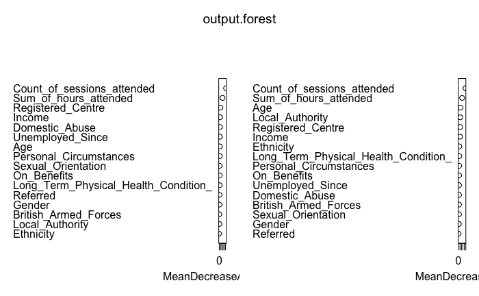

```r
varImpPlot(output.forest)
```

do gad now

```r
print(output.forest1)
```

```
Call:
 randomForest(formula = train_train$GAD_difference1 ~ ., data = train_train[,      c(6, 8, 9, 10, 11, 13, 14, 15, 16, 17, 18, 19, 20, 21, 22,          23)], importance = T)
               Type of random forest: classification
                     Number of trees: 500
No. of variables tried at each split: 4

        OOB estimate of  error rate: 35.26%
Confusion matrix:
     0   1 class.error
0 1643 282   0.1464935
1 1110 913   0.5486901
```

tunining gad model

```
mtry = 4  OOB error = 34.73%
Searching left ...
mtry = 3    OOB error = 34.57%
0.004376368 1e-05
mtry = 2    OOB error = 31.03%
0.1025641 1e-05
Searching right ...
mtry = 6    OOB error = 36.7%
-0.1828571 1e-05
```

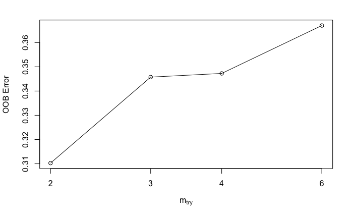

```r
bestmtry1 <- tuneRF(train_train[,c(6,8,9,10,11,13,14,15,16,17,18,19,20,21,22,23)], train_train$GAD_difference1, stepFactor=1.5, improve=1e-5, ntree=700)
```

run with tuned now

```r
print(output.forest1)
```

```
Call:
 randomForest(formula = train_train$GAD_difference1 ~ ., data = train_train[,      c(6, 8, 9, 10, 11, 13, 14, 15, 16, 17, 18, 19, 20, 21, 22,          23)], importance = T, mtry = 2)
               Type of random forest: classification
                     Number of trees: 500
No. of variables tried at each split: 2

        OOB estimate of  error rate: 31.46%
Confusion matrix:
     0    1 class.error
0 1547  378   0.1963636
1  864 1159   0.4270885
```

plot importance

```r
(importance(output.forest1))
```

```
                                              0          1 MeanDecreaseAccuracy MeanDecreaseGini
Age                                   6.2098622  2.0064618           5.81830395      146.7441957
Local_Authority                       0.0000000  0.0000000           0.00000000      128.9399032
Gender                                2.5751643 -1.9754567           0.02643745       24.4775782
Ethnicity                            -3.4565455  2.4701269          -0.35478212       54.2665113
Referred                              3.7354490 -5.7519899          -2.00128988        0.8611322
Registered_Centre                    10.9417778 -2.0789187           5.12918992      120.0822218
Sexual_Orientation                    1.3773911  3.9481515           4.15739337       31.9946071
Long_Term_Physical_Health_Condition_  2.9029249  2.3253749           4.09645520       53.6703105
British_Armed_Forces                 -0.3308559 -0.8380015          -0.90489563       32.9051717
Sum_of_hours_attended                21.3140669 17.8576637          26.31080861      246.4474518
Count_of_sessions_attended           42.4541013 41.8368137          50.26379536      455.0862181
Domestic_Abuse                        1.5080713  1.2264526           2.06312087       32.1286028
Personal_Circumstances                3.0868193  1.6265129           3.47674989       50.0431107
Income                                8.8211210  4.6956896           9.58434464      115.0663653
Unemployed_Since                      1.2639969  5.5262954           5.87374320       34.8042434
On_Benefits                           2.9385338  2.6332128           4.41411478       39.4812072
```

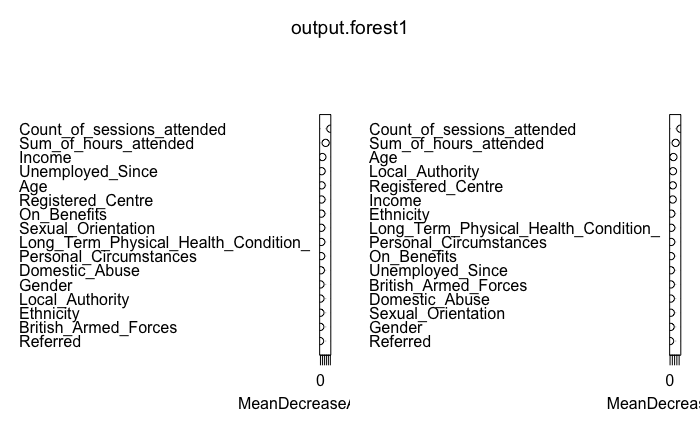

```r
varImpPlot(output.forest1)
```

GINI: GINI importance measures the average gain of purity by splits of a given variable. If the variable is useful, it tends to split mixed labeled nodes into pure single class nodes. Splitting by a permuted variables tend neither to increase nor decrease node purities. Permuting a useful variable, tend to give relatively large decrease in mean gini-gain. GINI importance is closely related to the local decision function, that random forest uses to select the best available split.

For Mean Decrease in Accuracy: Imagine you have a model built using a few variables including gender to predict if a person prefers coffee white or black. Take one variable and scramble it in a way that matches the distribution of the variable (e.g. if the variable is gender and 60% of the observations are male, than randomly assign male to 60% of the set - preserve the distribution but scramble the observations). Measure the predictive accuracy of the resulting tree. Repeat for each variable. The loss of accuracy is the Mean Decrease in Accuracy. Note that this is not causal - and in practical use I would focus on the ranking of the variable as a data point for further investigation rather than the actual magnitude of the measure.

For Mean Decrease in Gini (Index): Imagine you are looking at one of the nodes just above the leaves in a decision tree where you are predicting whether someone prefers white or black coffee. At this node, the model has the chance to split by multiple variables. It does this by searching for the variable to split where the split gives the lowest Gini index (lower is ‘purer’ / ‘better’). If the model chooses to split by gender, the subsequent left node (e.g. male) observations may all like black coffee and the right node (e.g. female) may all like white coffee (i.e. both nodes are 100% ‘pure’ and hits the lowest Gini Index of 0). If the model chooses another variable, the subsequent left and right nodes may have a mix of outcomes (i.e. be less pure, with a larger Gini index). This is not optimal and finally the model chooses to go with gender

=======================================================================================================

try binning the variables to improve performance

```r
binning <- woe.tree.binning(all_scores_users_1, all_scores_users_1$PHQ9_difference1, c('Age','Local_Authority','Gender','Ethnicity','Referred','Registered_Centre','Sexual_Orientation','Long_Term_Physical_Health_Condition_','British_Armed_Forces','Sum_of_hours_attended','Count_of_sessions_attended','Domestic_Abuse','Personal_Circumstances','Income','Unemployed_Since',
                                        'On_Benefits'))
```

```
Incorrect variable specification.
Target variable must have two distinct values (NAs are accepted).
```